# Swedish-day-wages

JJayes

06/09/2021

## Purpose

I want to have a look at the series of wages presented in the [Lund University Macroeconomic and Demographic Database](https://ekh.lu.se/en/research/economic-history-data/lu-madd/prices-and-wages) in the section on prices an wages.

The column names are silly - should fix them at some point.

### Plotting

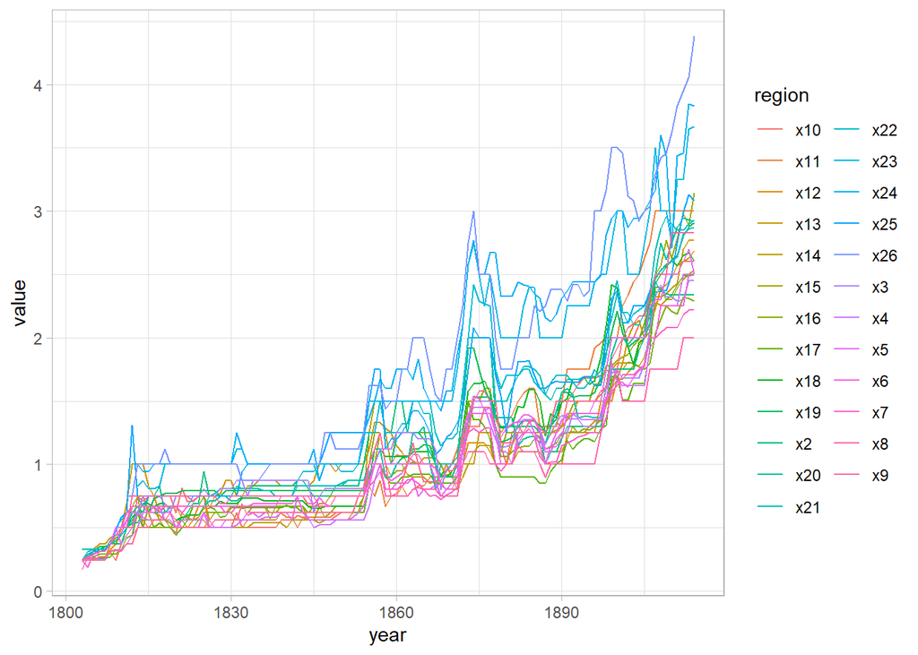

### Industrial prices

[interactive chart not shown]

TODO: `gghighlight` line graph with the highlight on the activity hat is clicked in the area plot.

Takeaway: wow look at how rapidly food products industries diminishes as a share of total manufacturing production! It would be interesting to look at how productivity increased in different areas of the country. So, we have the data on industrial output over time, and the number of factories in each area. We can link the census data based on who is employed where and have a really gritty measure of productivity growth per worker. We can answer - how did the increase in productivity affect workers wages also.

There are maybe three forces that drive the decline in food output as a share of total manufacturing output - a technology effect, a trade effect and a price effect.

On the one hand, you have an uptake of new technologies that expand the production frontier in the other industries that causes them to grow massively so that in proportion, food products industries make up less of the total value.

Then on the other hand there are productivity advances in the food manufacturing industry such that the price of food goes down as a share of household expenditure - and consequently as a share of total manufacturing output it will also go down. We have some amazing statistics on the number of masters, journeyman and apprentices.

*På svenska är de: mästare, gesän och lärlingar*

These are by industry and region. Can you imagine!! It would be so fun to build this series an show the different share of workers in each industry in each region, and compare that to output by region and industry.

Another interesting switch is from wood and wood products to pulp and paper. It seems that there is a shift just after 1900 - the decline in wood products as a share of total manufacturing output may be driven by the increase in output of pulp and paper products.

Wages of employees by activity from [Rodney Edvinson](https://ekh.lu.se/en/research/economic-history-data/lu-madd/prices-and-wages)

The series shows “U. Wages and salaries (including social benefits) of employees (current factor values, million SEK) of various types of activities.”

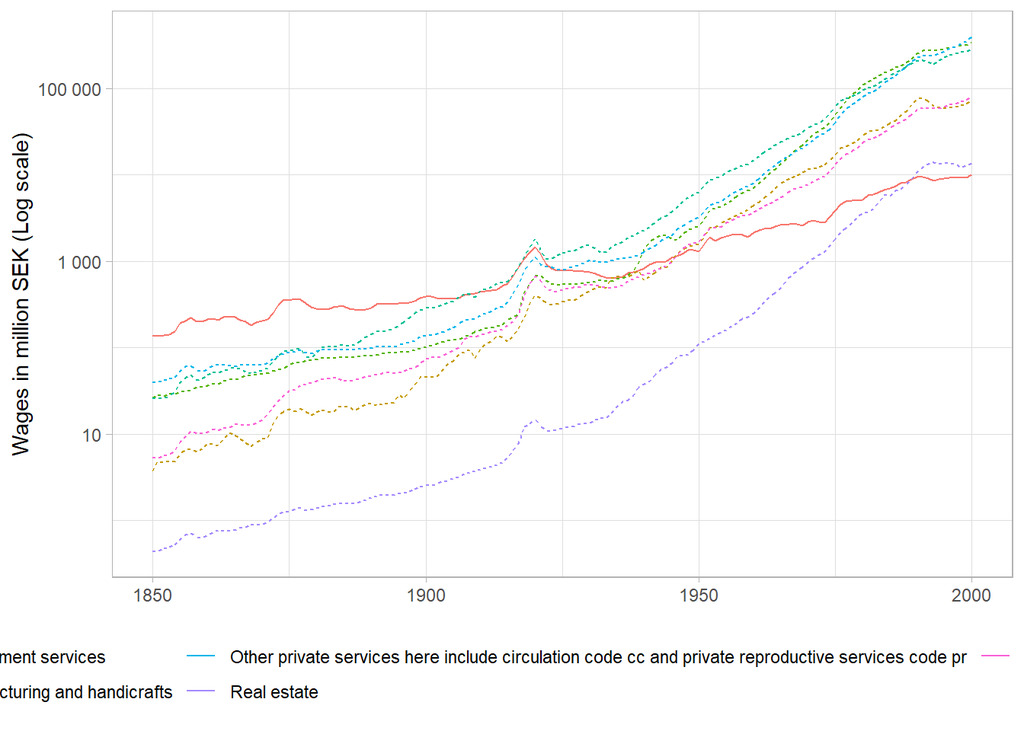

Can use this to show how wages in Agriculture drop from being the highest proportion of wages in the economy to the lowest in 2000.

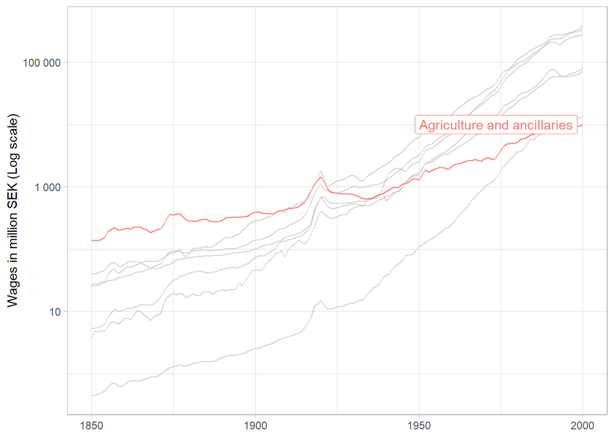

### What about population??

Population and Population Changes 1749–2020 from scb.se

Maybe some smoothing?

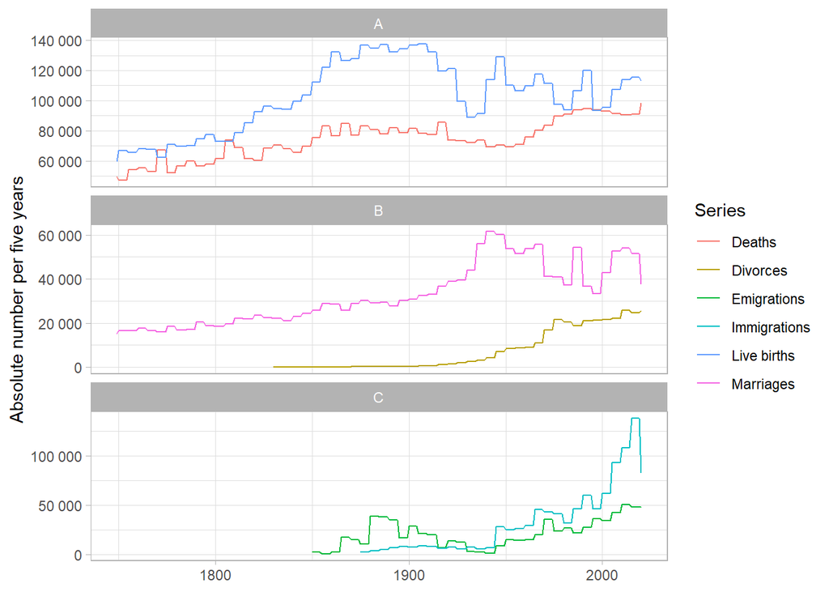

Same as a share of population

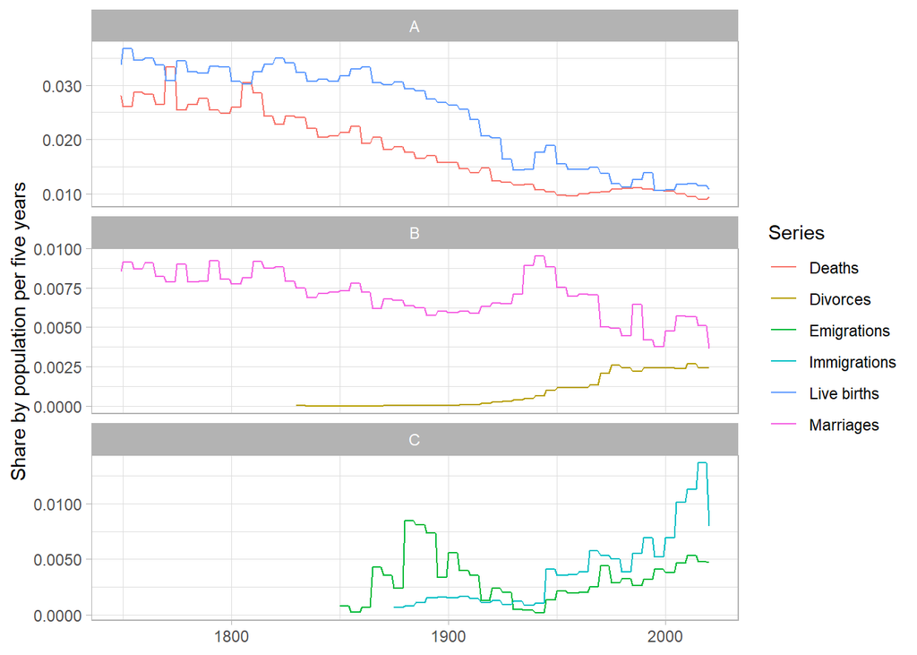

### Price series

Downloaded from the LU MEDD, originally published in [Ljungberg, J., Prices and Market Processes in Sweden 1885–1969 [Priser och marknadskrafter i Sverige 1885–1969] Lund, 1990.](https://ekh.lu.se/en/research/economic-history-data/lu-madd/prices-and-wages/industrial-products)

Note: Price Index 1910/12 = 100

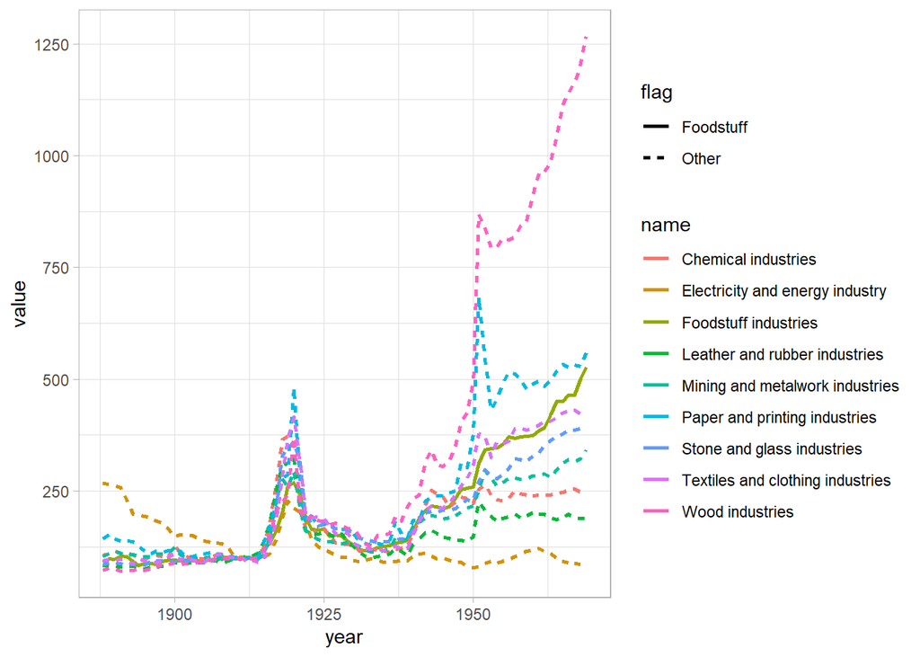

TODO: Maybe have a price index on one axis, and the share of total production on the other, and then on the third axis have time?

What about a comparison of the foodstuffs index compared to the total?

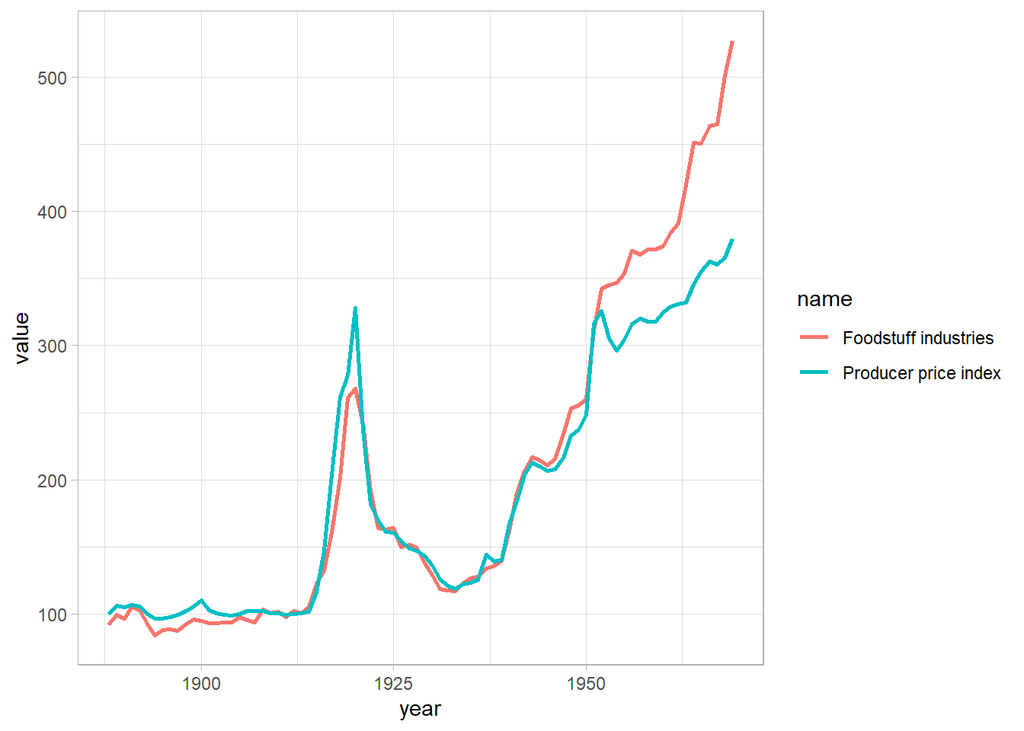

Go back and read Schön on “Peace, potatoes and something” - perhaps I can look more closely at the change in consumption patterns by households and tie this to the increasing agric. productivity?

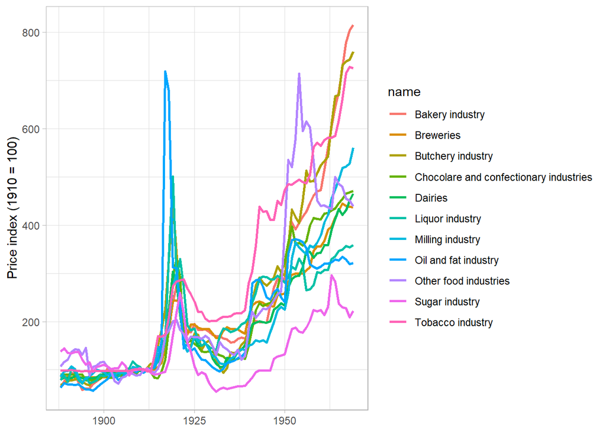

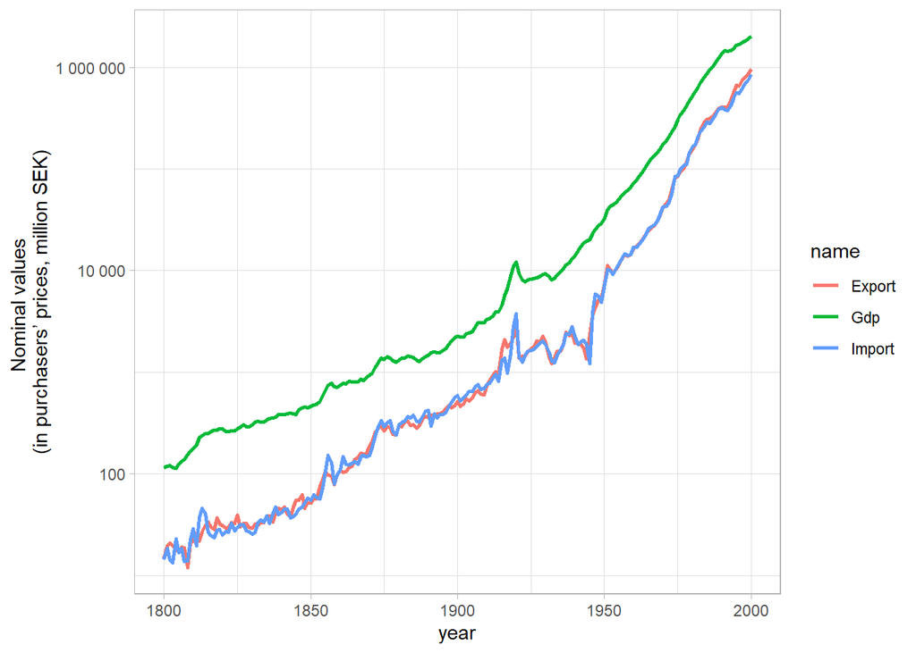

[interactive chart not shown]